# Symulacja bitwy

## Model wojenny Lanchester'a

W trakcie I Wojny Światowej Frederick W. Lanchester jako pierwszy zaproponował matematyczny model do opisu bitwy. Opiera się on na intuicyjnych równaniach różniczkowych:

\begin{equation} \begin{cases} \frac{dA}{dt} = -\beta B\\ \frac{dB}{dt} = -\alpha A \end{cases} \end{equation}

gdzie:

- A,B - liczba żołnieży obu stron
- $\alpha, \beta$ - odpowiednio siła ognia stron A i B

Model możemy rozszerzyć na więcej jednostek:

\begin{equation} \begin{cases} \frac{dU_{samolot}}{dt} = -\alpha_1 C_{samolot} - \alpha_2 C_{okręt} \\ \frac{dU_{czołg}}{dt} = -\beta_1 C_{samolot} - \beta_2 C_{okręt} - \beta_3 C_{czołg} \\ \frac{dU_{piechota}}{dt} = -\gamma_1 C_{samolot} - \gamma_2 C_{okręt} - \gamma_3 C_{czołg} - \gamma_4 C_{piechota} \\ \frac{dU_{okręt}}{dt} = -\delta_1 C_{samolot} - \delta_2 C_{okręt} \\ \frac{dC_{samolot}}{dt} = -\epsilon_1 U_{samolot} - \epsilon_2 U_{okręt} \\ \frac{dC_{czołg}}{dt} = -\zeta_1 U_{samolot} - \zeta_2 U_{okręt} - \zeta_3 U_{czołg} \\ \frac{dC_{piechota}}{dt} = -\eta_1 U_{samolot} - \eta_2 U_{okręt} - \eta_3 U_{czołg} - \eta_4 U_{piechota} \\ \frac{dC_{okręt}}{dt} = -\theta_1 U_{samolot} - \theta_2 U_{okręt} \\ \end{cases} \end{equation}

gdzie:

- $U_{*jednostka*}, C_{*jednostka*}$ - ilość jednostek danego typu w bitwie odpowiednio USA i Chin
- $*\alpha*$ - współczynnik obrażeń pomiędzy odpowiednimi jednostkami

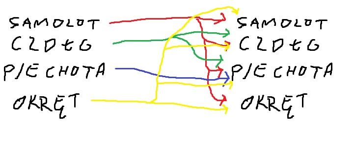

```python
from IPython.display import Image
Image("zaleznosci_jednostek.jpg")
```

## Model własny

```python
import numpy as np
from numpy.random import *
import random
import math
import matplotlib.pyplot as plt
import scipy.stats
import statistics
import pandas as pd
from sympy import *
```

```python
#piechota, czolgi, samoloty, statki
liczby_us1 = [0, 0, 55, 9]
liczby_ch1 = [0, 0, 80, 20]

#@jit(nopython=True)
def battle(liczby_us, liczby_ch, atakujacy, location="test", date=0):

    hp_US_all, hp_CH_all = [], []

    "Klasy jednostek: hp, dmg"
    piechota_us = [1, 1]
    czolg_us = [8000, 100]
    samolot_us = [4000, 150]
    statek_us = [25000, 150]

    piechota_ch = [1, 1]
    czolg_ch = [6500, 85]
    samolot_ch = [2400, 110]
    statek_ch = [18000, 140]

    "siły początkowe"
    hp_us = piechota_us[0]*liczby_us[0] + czolg_us[0]*liczby_us[1] + samolot_us[0]*liczby_us[2] + statek_us[0]*liczby_us[3]
    dmg_us = piechota_us[1]*liczby_us[0] + czolg_us[1]*liczby_us[1] + samolot_us[1]*liczby_us[2] + statek_us[1]*liczby_us[3]

    hp_ch = piechota_ch[0]*liczby_ch[0] + czolg_ch[0]*liczby_ch[1] + samolot_ch[0]*liczby_ch[2] + statek_ch[0]*liczby_ch[3]
    dmg_ch = piechota_ch[1]*liczby_ch[0] + czolg_ch[1]*liczby_ch[1] + samolot_ch[1]*liczby_ch[2] + statek_ch[1]*liczby_ch[3]

    stan = []
    pips = [0,0]
    stan_walki = 5
    dzien = 0

#     print("Date: ", str(date), ". Battle of ", location, sep="")
#     print("----------")
#     print("Time\t: ", dzien, sep="")
#     print("Pips\t: ", pips, sep="")
#     print("hpUSA\t: ", hp_us, sep="")
#     print("dmgUSA\t: ", dmg_us, sep="")
#     print("hpChin\t: ", hp_ch, sep="")
#     print("dmgChin\t: ", dmg_ch, sep="")
#     print("Status\t: ", stan_walki, sep="")

    "Pętla wojny"
    while 10  > stan_walki > 0 and hp_us > 0 and hp_ch > 0:

        "Modyfikatory i eventy"
        pips = [random.randint(1, 5), random.randint(1, 5)]
        trzesienie = random.randint(1, 10000)

        if atakujacy == "USA":
            #Stany atakuja pierwsze
            hp_ch2 = hp_ch - dmg_us*pips[0]
            dmg_ch = dmg_ch*(hp_ch2/hp_ch)
            hp_ch = hp_ch2

            hp_us2 = hp_us - dmg_ch*pips[1]
            dmg_us = dmg_us*(hp_us2/hp_us)
            hp_us = hp_us2
        else:
            #chiny atakują pierwsze
            hp_us2 = hp_us - dmg_ch*pips[1]
            dmg_us = dmg_us*(hp_us2/hp_us)
            hp_us = hp_us2

            hp_ch2 = hp_ch - dmg_us*pips[0]
            dmg_ch = dmg_ch*(hp_ch2/hp_ch)
            hp_ch = hp_ch2

        if trzesienie == 69:
            print("Trzesienie ziemi")
            hp_us = hp_us/2
            dmg_us = dmg_us/2
            hp_ch = hp_ch/2
            dmg_ch = dmg_ch/2

        hp_US_all.append(hp_us)
        hp_CH_all.append(hp_ch)

        stan_walki = stan_walki + hp_us/hp_ch - hp_ch/hp_us

        if stan_walki > 10:
            stan_walki = 10
        elif stan_walki < 0 :
            stan_walki = 0

        stan.append(stan_walki)
        dzien = dzien + 1

#         print("----------")
#         print("Time\t: ", dzien, sep="")
#         print("Pips\t: ", pips, sep="")
#         print("hpUSA\t: ", hp_us, sep="")
#         print("dmgUSA\t: ", dmg_us, sep="")
#         print("hpChin\t: ", hp_ch, sep="")
#         print("dmgChin\t: ", dmg_ch, sep="")
#         print("Status\t: ", stan_walki, sep="")


#     if stan_walki >= 10:
#         print("Wygrana USA po: ", dzien, " godzinach")
#     else:
#         print("Wygrana Chin po: ", dzien, " godzinach")

    return stan, dzien, hp_US_all, hp_CH_all
```

## Przykładowa bitwa

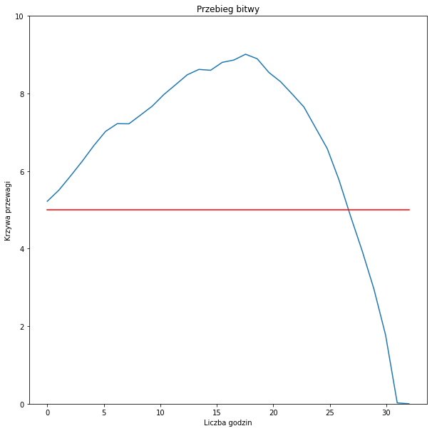

```python
import pylab as p
#piechota, czolgi, samoloty, statki
liczby_us_random = [20000, 100, 120, 20]
liczby_ch_random = [30000, 150, 70, 30]

status, d, u, c = battle(liczby_us_random, liczby_ch_random, "China")
t = np.linspace(0, d, d)
base = [5 for i in status]
p.figure(figsize=(10,10))
ax = p.subplot(111)
ax.plot(t, status)
ax.plot(t, base, color='red')
ax.set_ybound(0, 10)
p.title("Przebieg bitwy")
p.ylabel("Krzywa przewagi")
p.xlabel("Liczba godzin")
p.show()
```

```python
#piechota, czolgi, samoloty, statki
liczby_us_random = [20000, 100, 120, 20]
liczby_ch_random = [30000, 150, 70, 30]
us = 0
n = 1000

for i in range(n):
    status, d, u, c = battle(liczby_us_random, liczby_ch_random, "China")
    if status[-1] == 10:
        us = us + 1
print("Zwyciestwa USA na ", n, " symulacji: ", us)
```

```
Trzesienie ziemi
Zwyciestwa USA na  1000  symulacji:  295
```

## Pierwsza bitwa

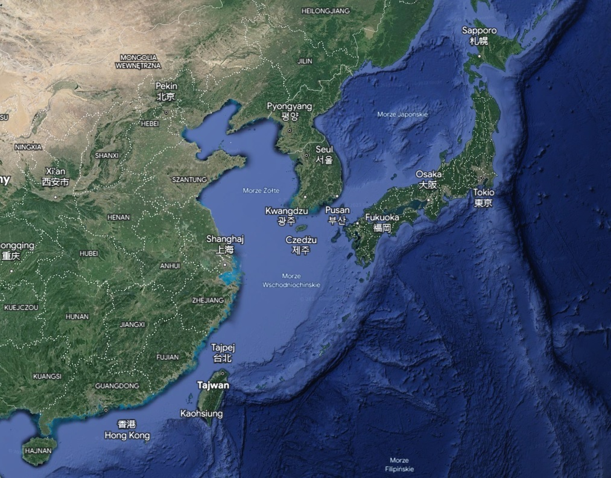

```python
from IPython.display import Image
Image("mapa1.jpg")
```

[figure not shown]

```python
from IPython.display import Image
Image("mapa2.jpg")
```

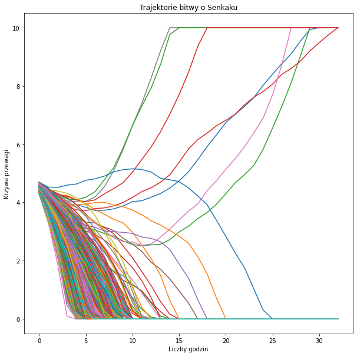

```python
status, day, USA_hp, CH_hp = [], 0, [], []
for i in range(1000):
    s, d, u, c = battle(liczby_us1, liczby_ch1, "Chiny")
    status.append(s)
    USA_hp.append(u)
    CH_hp.append(c)
    if d > day:
        day = d

for s in status:
    if len(s) < day:
        for _ in range(day - len(s)):
            s.append(s[-1])

plt.figure(figsize=(10,10))
for s in status:
    plt.plot(s)
plt.title("Trajektorie bitwy o Senkaku")
plt.xlabel("Liczby godzin")
plt.ylabel("Krzywa przewagi")
plt.show()
```

## Porównanie symulacji z modelem Lanchester'a

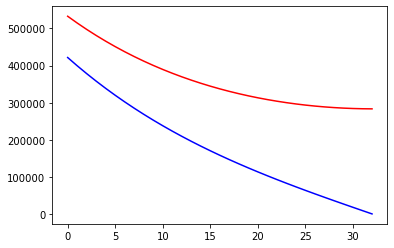

```python
Us, Uo, Cs, Co = 55, 9, 80, 20
hp_US, hp_CH = [], []
for i in range(1000):
    dUs = -110/4000*Cs - 140/4000*Co
    dUo = -110/25000*Cs - 140/25000*Co
    dCs = -150/2400*Us - 150/2400*Uo
    dCo = -150/18000*Us - 150/18000*Uo
    Us += dUs
    Uo += dUo
    Cs += dCs
    Co += dCo
    if Us <= 0 + Uo <= 0 or Cs <= 0 + Co <= 0:
        break
    hp_US.append(Us*4000 + Uo*25000)
    hp_CH.append(Cs*2400 + Co*18000)

hp_CH, hp_US = np.array(hp_CH), np.array(hp_US)
plt.plot(hp_CH, color='red')
plt.plot(hp_US, color="blue")
plt.show()
```

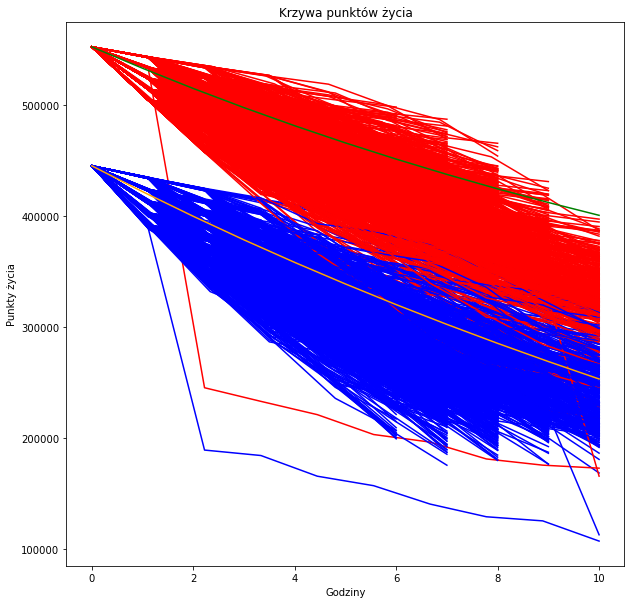

```python
"Bazy wojskowe"
#bitwa rozpoczynająca o senkaku
liczby_us_senkaku = [0, 0, 55, 9]
liczby_ch_senkaku = [0, 0, 80, 20]

def battle(liczby_us, liczby_ch, atakujacy):

    "Klasy jednostek: hp, dmg"
    piechota_us = [1, 1]
    czolg_us = [8000, 100]
    samolot_us = [4000, 150]
    statek_us = [25000, 150]

    piechota_ch = [1, 1]
    czolg_ch = [6500, 85]
    samolot_ch = [2400, 110]
    statek_ch = [18000, 140]

    "siły początkowe"
    hp_us = piechota_us[0]*liczby_us[0] + czolg_us[0]*liczby_us[1] + samolot_us[0]*liczby_us[2] + statek_us[0]*liczby_us[3]
    dmg_us = piechota_us[1]*liczby_us[0] + czolg_us[1]*liczby_us[1] + samolot_us[1]*liczby_us[2] + statek_us[1]*liczby_us[3]

    hp_ch = piechota_ch[0]*liczby_ch[0] + czolg_ch[0]*liczby_ch[1] + samolot_ch[0]*liczby_ch[2] + statek_ch[0]*liczby_ch[3]
    dmg_ch = piechota_ch[1]*liczby_ch[0] + czolg_ch[1]*liczby_ch[1] + samolot_ch[1]*liczby_ch[2] + statek_ch[1]*liczby_ch[3]
    stan = []
    stan_walki = 5
    dzien = 0
    tab_hp_us = [hp_us]
    tab_hp_ch = [hp_ch]

    "Pętla wojny"
    while 10  > stan_walki > 0:

        "Modyfikatory i eventy"
        pips = [random.randint(1, 5), random.randint(1, 5)]
        trzesienie = random.randint(1, 5000)

        if atakujacy == "USA":
            #Stany atakuja pierwsze
            hp_ch2 = hp_ch - dmg_us*pips[0]
            dmg_ch = dmg_ch*(hp_ch2/hp_ch)
            hp_ch = hp_ch2

            hp_us2 = hp_us - dmg_ch*pips[1]
            dmg_us = dmg_us*(hp_us2/hp_us)
            hp_us = hp_us2
        else:
            #chiny atakują pierwsze
            hp_us2 = hp_us - dmg_ch*pips[1]
            dmg_us = dmg_us*(hp_us2/hp_us)
            hp_us = hp_us2

            hp_ch2 = hp_ch - dmg_us*pips[0]
            dmg_ch = dmg_ch*(hp_ch2/hp_ch)
            hp_ch = hp_ch2

        if hp_us <= 0:
            return "Zwyciestwo Chin"
        elif hp_ch <= 0:
            return "Zwycięstwo USA"

        if trzesienie == 69:
            #print("Trzesienie ziemi")
            hp_us = hp_us/2
            dmg_us = dmg_us/2
            hp_ch = hp_ch/2
            dmg_ch = dmg_ch/2


        stan_walki = stan_walki + hp_us/hp_ch - hp_ch/hp_us

        if stan_walki > 10:
            stan_walki = 10
        elif stan_walki < 0 :
            stan_walki = 0

        stan.append(stan_walki)
        dzien = dzien + 1

        tab_hp_us.append(hp_us)
        tab_hp_ch.append(hp_ch)

    t=np.linspace(0,min([dzien+1,10]),min([dzien+1,10]))
    plt.plot(t, tab_hp_us[:10], color='blue')
    plt.plot(t, tab_hp_ch[:10], color='red')

plt.figure(figsize=(10,10))

for i in range(1000):
  battle(liczby_us_senkaku, liczby_ch_senkaku, "USA")


Us, Uo, Cs, Co = 55, 9, 80, 20
hp_US, hp_CH = [Us*4000 + Uo*25000], [Cs*2400 + Co*18000]
for i in range(1000):
    dUs = -110/4000*Cs - 140/4000*Co
    dUo = -110/25000*Cs - 140/25000*Co
    dCs = -150/2400*Us - 150/2400*Uo
    dCo = -150/18000*Us - 150/18000*Uo
    if Us < 0:
      Us=0
    else :
      Us += dUs
    if Uo < 0:
      Uo=0
    else :
      Uo += dUo
    if Cs < 0:
      Cs=0
    else :
      Cs += dCs
    if Co < 0:
      Co=0
    else :
      Co += dCo
    if (Us + Uo )<= 0 or (Cs + Co )<= 0:
        break
    hp_US.append(Us*4000 + Uo*25000)
    hp_CH.append(Cs*2400 + Co*18000)


plt.plot(hp_US[:11], color='orange')
plt.plot(hp_CH[:11], color='green')
plt.title("Krzywa punktów życia")
plt.xlabel("Godziny")
plt.ylabel("Punkty życia")
plt.show()
```

## Bibliografia

https://www.researchgate.net/publication/221088038_The_mathematical_model_based_on_the_battle_of_Berlin  
https://www.rand.org/paf/projects/us-china-scorecard.html  
https://en.wikipedia.org/wiki/Lanchester%27s_laws  
https://www.google.pl/intl/pl/earth/  
https://pl.wikipedia.org/wiki/Lista_okr%C4%99t%C3%B3w_United_States_Navy_w_czynnej_s%C5%82u%C5%BCbie